# Simulations OVB/type M trade-off: IV

Vincent Bagilet https://www.sipa.columbia.edu/experience-sipa/sipa-profiles/vincent-bagilet (Columbia University)https://www.columbia.edu/ , Léo Zabrocki https://www.parisschoolofeconomics.eu/en/ (Paris School of Economics)https://www.parisschoolofeconomics.eu/en/  
2021-10-27

## An illustrative example

To illustrate this trade-off between OVB and type M error, we consider a standard application of the IV design in environmental economics.

### Modelisation choices

The DGP can be represented using the following Directed Acyclic Graph (DAG):

[figure not shown]

### Data generation

We write a simple function that generates the data. It takes as input the values of the different parameters and returns a data frame containing all the variables for this analysis.

```r
generate_data_IV <- function(N = 1000,
                             sigma_u = 1,
                             sigma_z = 1,
                             sigma_ex = 1,
                             sigma_ey = 1,
                             alpha_y = 0,
                             alpha_x = 0,
                             beta = 1, #treatment effect
                             gamma = 0.3, #IV strength
                             delta = 2 #OVB intensity
                             ) {

  data <- tibble(id = 1:N) %>%
    mutate(
      z = rnorm(nrow(.), 0, sigma_z),
      u = rnorm(nrow(.), 0, sigma_u),
      e_x = rnorm(nrow(.), 0, sigma_ex),
      e_y = rnorm(nrow(.), 0, sigma_ey),
      x = alpha_x + gamma*z + delta*u + e_x,
      y = alpha_y + beta*x + delta*u + e_y
    )

  return(data)
}
```

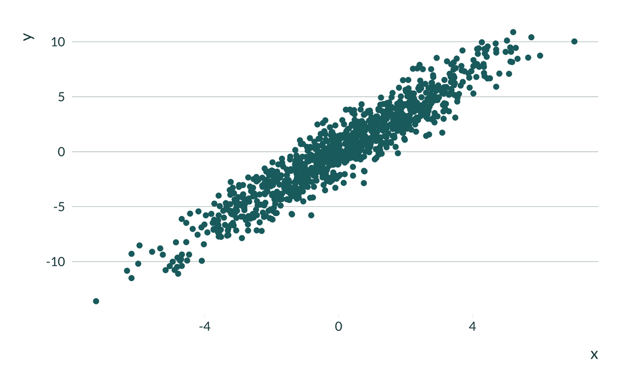

### Estimation

After generating the data, we can run an estimation. We want to compare the IV and the OLS for different IV strength values. Hence, we need to estimate both an IV and an OLS and return both set of outcomes of interest.

```r
estimate_IV <- function(data) {
  reg_IV <- ivreg(
    data = data,
    formula = y ~ x | z
    ) %>%
    broom::tidy() %>%
    filter(term == "x") %>%
    rename(p_value = p.value, se = std.error) %>%
    select(estimate, p_value, se) %>%
    mutate(model = "IV")

  reg_OLS <- ivreg(
    data = data,
    formula = y ~ x
    ) %>%
    broom::tidy() %>%
    filter(term == "x") %>%
    rename(p_value = p.value, se = std.error) %>%
    select(estimate, p_value, se) %>%
    mutate(model = "OLS")

  reg <- reg_IV %>%
    rbind(reg_OLS)

  return(reg)
}
```

### One simulation

```r
compute_simulation_IV <- function(N = 500,
                                  sigma_u = 1,
                                  sigma_z = 1,
                                  sigma_ex = 1,
                                  sigma_ey = 1,
                                  alpha_y = 0,
                                  alpha_x = 0,
                                  beta = 1,
                                  gamma = 0.3,
                                  delta = 2) {
  generate_data_IV(
    N = N,
    sigma_u = sigma_u,
    sigma_z = sigma_z,
    sigma_ex = sigma_ex,
    sigma_ey = sigma_ey,
    alpha_y = alpha_y,
    alpha_x = alpha_x,
    beta = beta,
    gamma = gamma,
    delta = delta
  ) %>%
  estimate_IV() %>%
  mutate(
    gamma = gamma,
    delta = delta
  )
}
```

Here is an example of an output of this function.

| estimate | p_value | se | model | gamma | delta |
| --- | --- | --- | --- | --- | --- |
| 0.6934037 | 0.2009316 | 0.5414694 | IV | 0.3 | 2 |
| 1.7899914 | 0.0000000 | 0.0269092 | OLS | 0.3 | 2 |

### All simulations

We will run the simulations for different sets of parameters by mapping our `compute_simulation_IV` function on each set of parameters. We thus create a table with all the values of the parameters we want to test `param_IV`. Note that in this table each set of parameters appears `n_iter` times as we want to run the analysis $n_{iter}$ times for each set of parameters.

```r
vect_gamma <- c(seq(0.05, 0.4, 0.05), seq(0.4, 1, 0.1))
vect_delta <- c(0.4)
n_iter <- 1000

param_IV <- crossing(vect_gamma, vect_delta) %>%
  rename(gamma = vect_gamma, delta = vect_delta) %>%
  crossing(rep_id = 1:n_iter) %>%
  select(-rep_id)
```

We then run the simulations by mapping our `compute_simulation_IV` function on `param_IV`.

```r
tic()
simulations_IV <- pmap_dfr(param_IV, compute_simulation_IV)
beep()
toc()

# saveRDS(simulations_IV, here("Outputs/simulations_IV.RDS"))
```

## Analysis of the results

### Quick exploration

First, we quickly explore the results.

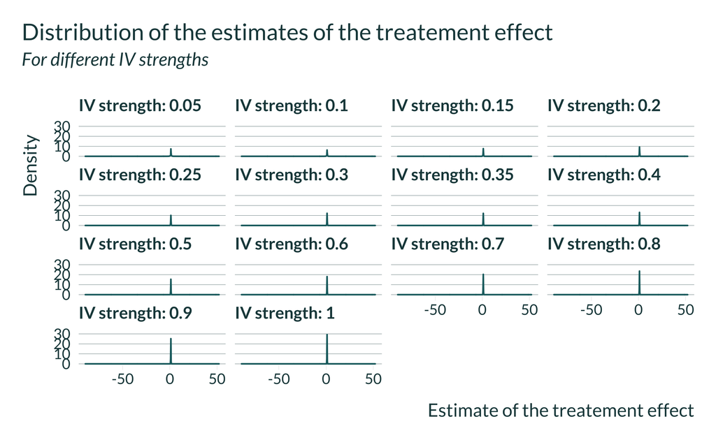

### Computing bias and type M

We want to compare $\mathbb{E}[\beta_0 - \widehat{\beta_{RDD}}]$ and $\mathbb{E}[|\beta_0 - \widehat{\beta_{RDD}}||signif]$. The first term represents the bias and the second term represents the type M error. This terms depend on the effect size. To enable comparison across simulation and getting terms independent of effect sizes, we also compute the average of the ratios between the estimate and the true effect, conditional on significance.

```r
summarise_simulations <- function(data, true_effect = 1) {
  data %>%
    mutate(significant = (p_value <= 0.05)) %>%
    group_by(delta, gamma, model) %>%
    summarise(
      power = mean(significant, na.rm = TRUE)*100,
      type_m = mean(ifelse(significant, abs(estimate - true_effect), NA), na.rm = TRUE),
      bias_sign = mean(ifelse(significant, estimate/true_effect, NA), na.rm = TRUE),
      bias_all = mean(estimate/true_effect, na.rm = TRUE),
      .groups  = "drop"
    ) %>%
    ungroup()
}

summary_simulations_IV <- summarise_simulations(simulations_IV)
# saveRDS(summary_simulations_IV, here("Outputs/summary_simulations_IV.RDS"))
```

### Graph

To analyze our results, we build a unique and simple graph:

[figure not shown]